# Assignment 5: Visualization Audit

Author

Jade Lee

## Question

How did mean BMI differ between women and men aged 20-80 across NHANES cycles in the prepared class dataset?

## Load the data

```r
library(tidyverse)

nhanes <- read_csv("examples/nhanes-equity/data/nhanes_equity_v6.csv",
                   show_col_types = FALSE)
```

## Check exclusions

```r
nhanes |>
  filter(Age >= 20, Age <= 80) |>
  summarise(
    adults_20_80 = n(),
    missing_bmi = sum(is.na(BMI)),
    missing_gender = sum(is.na(Gender))
  )
```

```
# A tibble: 1 × 3
  adults_20_80 missing_bmi missing_gender
         <int>       <int>          <int>
1        57137        1009              0
```

Of 57,137 adults aged 20-80, 1,009 (about 1.8%) had missing BMI and were excluded. No records were missing gender.

## Descriptive summary

```r
# AI prompt: change the income summary to gender, adults 20-80, all cycles
# Verified: 22 rows (11 cycles x 2 genders); the smallest group has 1,923 people

bmi_by_gender <- nhanes |>
  filter(!is.na(BMI), Age >= 20, Age <= 80) |>
  group_by(Cycle, Gender) |>
  summarise(n = n(), mean_bmi = round(mean(BMI), 2), .groups = "drop")

bmi_by_gender
```

```
# A tibble: 22 × 4
   Cycle     Gender     n mean_bmi
   <chr>     <chr>  <int>    <dbl>
 1 1999-2000 Female  2199     29.1
 2 1999-2000 Male    1923     27.8
 3 2001-2002 Female  2319     28.7
 4 2001-2002 Male    2111     27.9
 5 2003-2004 Female  2199     29.1
 6 2003-2004 Male    2078     28.1
 7 2005-2006 Female  2291     29.3
 8 2005-2006 Male    2099     28.6
 9 2007-2008 Female  2861     29.3
10 2007-2008 Male    2746     28.6
# ℹ 12 more rows
```

## Draft plot

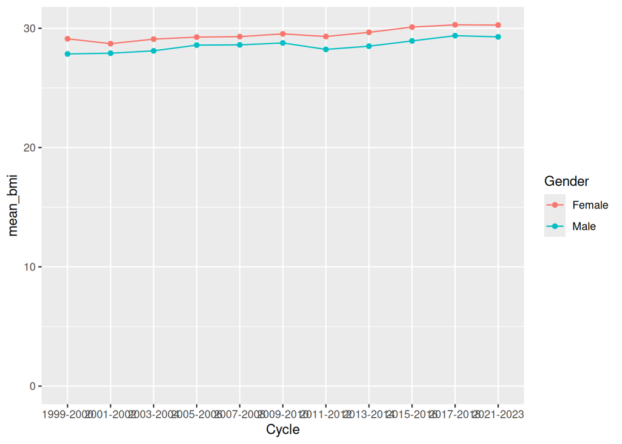

```r
# AI prompt: line plot of mean BMI by cycle, one line per gender, y-axis from 0
# Verified: 22 points match bmi_by_gender; lines look almost flat
draft_plot <- ggplot(bmi_by_gender,
                     aes(x = Cycle, y = mean_bmi, color = Gender, group = Gender)) +
  geom_line() +
  geom_point() +
  expand_limits(y = 0)

draft_plot
```

My first draft had three problems:

- The y-axis started at 0, so the lines looked almost flat and the changes of about 1-2 BMI units across cycles were hard to see.
- The cycle labels on the x-axis overlapped and could not be read.
- It had no title, subtitle, or caption, and the y-axis label was the raw variable name (`mean_bmi`). A reader could not tell that the plot showed adults only or that the summary was unweighted.

## Corrected plot

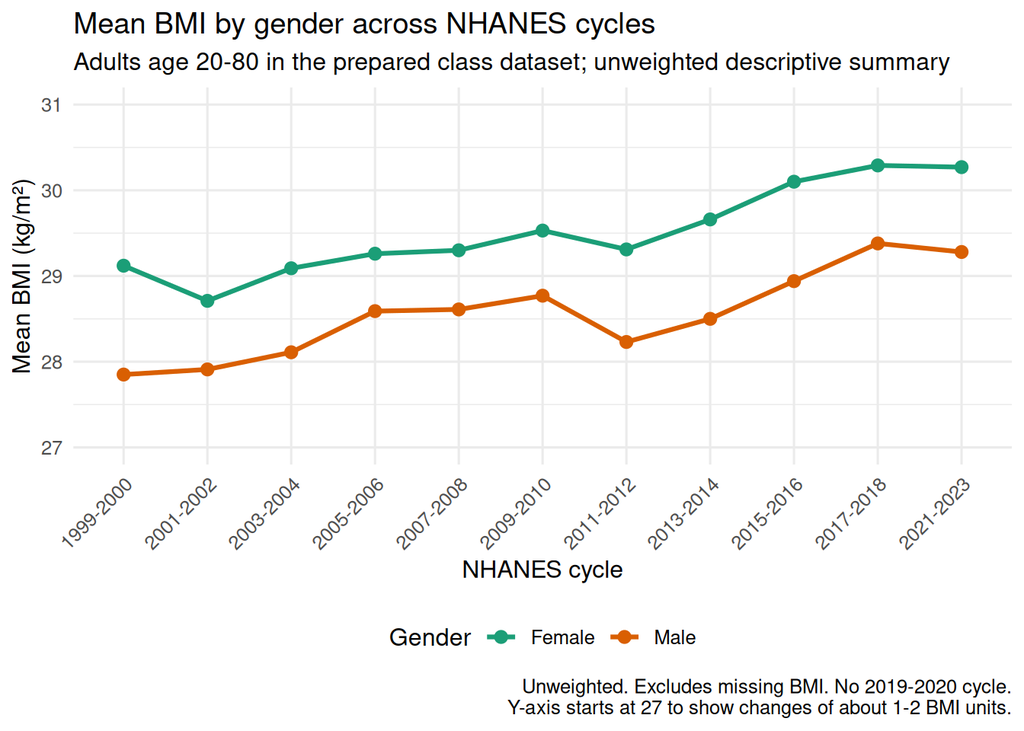

Mean BMI by gender across NHANES cycles, adults aged 20-80 in the prepared NHANES Health Equity class dataset. The summary is descriptive and unweighted. Records with missing BMI were excluded. There is no 2019-2020 cycle. The y-axis starts at 27, not 0, to show changes of about 1-2 BMI units; BMI cannot be 0, and a line chart compares positions, not bar lengths. The plot shows patterns, not causal effects or population estimates.

```r
# AI prompt: x-axis labels overlap and the lines look flat with the y-axis at 0. fix both
# Verified: x-axis labels are readable after rotating; I compared the plot with y from 0 and from 27 and kept 27 because the ups and downs were visible; points match bmi_by_gender


final_plot <- ggplot(bmi_by_gender,
                     aes(x = Cycle, y = mean_bmi, color = Gender, group = Gender)) +
  geom_line(linewidth = 1.1) +
  geom_point(size = 2.5) +
  coord_cartesian(ylim = c(27, 31)) +
  scale_color_brewer(palette = "Dark2") +
  labs(
    title = "Mean BMI by gender across NHANES cycles",
    subtitle = "Adults age 20-80 in the prepared class dataset; unweighted descriptive summary",
    x = "NHANES cycle",
    y = "Mean BMI (kg/m²)",
    color = "Gender",
    caption = "Unweighted. Excludes missing BMI. No 2019-2020 cycle.\nY-axis starts at 27 to show changes of about 1-2 BMI units."
  ) +
  theme_minimal(base_size = 12) +
  theme(
    axis.text.x = element_text(angle = 45, hjust = 1),
    legend.position = "bottom"
  )

final_plot
```

```r
ggsave(
  "assignments/assignment05-visualization/submission/corrected-plot.png",
  plot = final_plot,
  width = 7,
  height = 5
)
```

## What changed and why

I compared women and men because Gender has no missing values and both groups are large in every cycle, so the comparison adds no extra exclusions and has no small groups.

I applied the lessons from auditing the flawed plot to my own draft. I kept only adults aged 20-80, because the flawed plot said “adults” but included children as young as 2. I used all 11 cycles instead of two endpoints, so the reader sees the real ups and downs.

In my draft, the y-axis started at 0 and the lines looked almost flat, so the changes across cycles were hard to see. Because BMI cannot be 0 and a line chart compares positions rather than bar lengths, I zoomed in to 27-31 instead. I used `coord_cartesian()` to set the range, and I stated the axis choice in the caption. The flawed plot also zoomed in, but it hid that choice and paired it with causal wording.